# Practicum 1

Victoria Liebsch-Aljawahiri, Eni Cerma, Vrunda Patel

2022-10-16

## Preparations

Multiple libraries were loaded for use.

```r
# Load required libraries
library(tidyverse)
library(stringr)
library(skimr)
library(janitor)
library(scales)
library(readr)
library(XML)
library(xml2)
library(glue)
library(viridis)
```

# Part 1

Some of the following questions will use the `mtcars` pre-loaded data set.

## Question 1

Create a dataframe with 4 variables. The 4 variables should be `doctor_type`, `doctor_lastname`, `location`, `AVG_Rating`. The variable `doctor_type` should contain 4 inputs (PCP, Psychiatrist, Surgeon, Anesthesia). The variable `doctor_lastname` should contain 4 inputs (Smith, Dame, Jones, Zayas). The variable `location` should contain 4 inputs (MA, ME, NH, VT). The variable `AVG_Rating` should contain 4 inputs (7,9,8,9). Print the dataframe.

```r
# Make variables
doctor_type <- c("PCP", "Psychiatrist", "Surgeon", "Anesthesia")

doctor_lastname <- c("Smith", "Dame", "Jones", "Zayas")

location <- c("MA", "ME", "NH", "VT")

AVG_rating <- c(7, 9, 8, 9)

# Make dataframe
doctor.df <- data.frame(doctor_type, doctor_lastname, location, AVG_rating)

# Show dataframe
doctor.df
```

```
##    doctor_type doctor_lastname location AVG_rating
## 1          PCP           Smith       MA          7
## 2 Psychiatrist            Dame       ME          9
## 3      Surgeon           Jones       NH          8
## 4   Anesthesia           Zayas       VT          9
```

## Question 2

Using the dataframe above… Select row 1 in column 2, what was selected? Select rows 2 through 4, what was selected? Select the last column, what was selected?

```r
# Select row 1 in column 2
doctor.df[1, 2]
```

```
## [1] "Smith"
```

```r
# Select rows 2 - 4
doctor.df[2:4,]
```

```
##    doctor_type doctor_lastname location AVG_rating
## 2 Psychiatrist            Dame       ME          9
## 3      Surgeon           Jones       NH          8
## 4   Anesthesia           Zayas       VT          9
```

```r
# Select the last column
rev(doctor.df)[1]
```

```
##   AVG_rating
## 1          7
## 2          9
## 3          8
## 4          9
```

Row 1 in column 2 results in the “Smith” `doctor_lastname`. Rows 2 through 4 results in the observation for “Psychiatrist”, “Surgeon” and “Anesthesia”. Selecting the last column, shows the `Avg_Rating` column.

## Question 3

Using the dataset Mtcars create a scatterplot showing the relations between any two variables of your choosing. Explain why you picked those variables. Each point should also be based on a color scheme of your choosing.

```r
# Inspect data
head(mtcars)
```

```
##                    mpg cyl disp  hp drat    wt  qsec vs am gear carb
## Mazda RX4         21.0   6  160 110 3.90 2.620 16.46  0  1    4    4
## Mazda RX4 Wag     21.0   6  160 110 3.90 2.875 17.02  0  1    4    4
## Datsun 710        22.8   4  108  93 3.85 2.320 18.61  1  1    4    1
## Hornet 4 Drive    21.4   6  258 110 3.08 3.215 19.44  1  0    3    1
## Hornet Sportabout 18.7   8  360 175 3.15 3.440 17.02  0  0    3    2
## Valiant           18.1   6  225 105 2.76 3.460 20.22  1  0    3    1
```

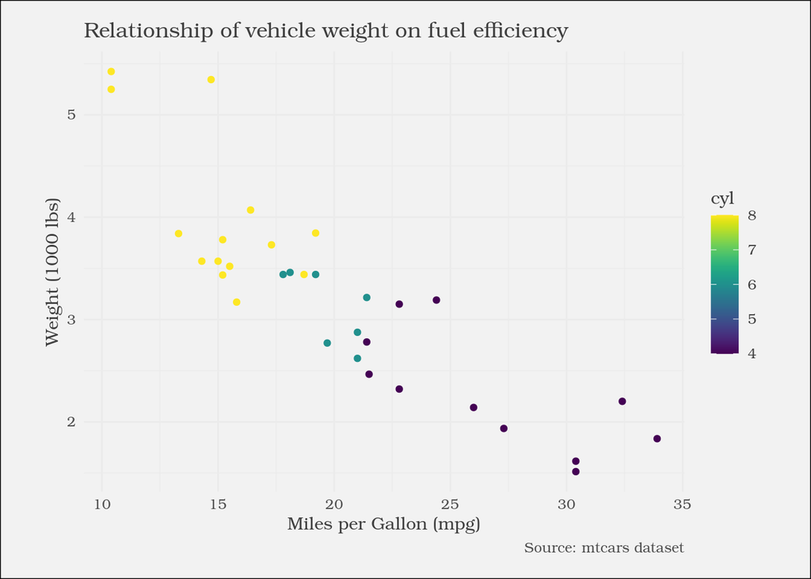

```r
# Theme for plot
cool_theme <- function() {
  theme_minimal() +
  theme(
    text = element_text(family = "Bookman", color = "gray25"),
    plot.subtitle = element_text(size = 12),
    plot.caption = element_text(color = "gray30"),
    plot.background = element_rect(fill = "gray95"),
    plot.margin = unit(c(5, 10, 5, 10), units = "mm")
  )
}

# Make graph
ggplot(mtcars, aes(x = mpg, y = wt, color = cyl)) +
  geom_point() +
  labs(title = "Relationship of vehicle weight on fuel efficiency",
       x = "Miles per Gallon (mpg)",
       y = "Weight (1000 lbs)",
       caption = "Source: mtcars dataset") +
  cool_theme() +
  scale_color_viridis(option = "D")
```

The scatterplot shows the relationship between fuel efficiency and vehicle weight. We chose these variables because we wanted to see how vehicle weight impacts fuel efficiency. From the graph below we can see that the more a vehicle weights, the lower the fuel efficiency. Additionally, the higher larger the cylinder the less fuel efficient.

## Question 4

Using the dataset `mtcars` perform a summary statistic on the dataset and calculate the pearson coefficient of the correlation R picking two variables of choice. Explain why you picked those variables and explain the purpose of a pearson coefficient.

```r
# Summary statistics
summary(mtcars)
```

```
##       mpg             cyl             disp             hp
##  Min.   :10.40   Min.   :4.000   Min.   : 71.1   Min.   : 52.0
##  1st Qu.:15.43   1st Qu.:4.000   1st Qu.:120.8   1st Qu.: 96.5
##  Median :19.20   Median :6.000   Median :196.3   Median :123.0
##  Mean   :20.09   Mean   :6.188   Mean   :230.7   Mean   :146.7
##  3rd Qu.:22.80   3rd Qu.:8.000   3rd Qu.:326.0   3rd Qu.:180.0
##  Max.   :33.90   Max.   :8.000   Max.   :472.0   Max.   :335.0
##       drat             wt             qsec             vs
##  Min.   :2.760   Min.   :1.513   Min.   :14.50   Min.   :0.0000
##  1st Qu.:3.080   1st Qu.:2.581   1st Qu.:16.89   1st Qu.:0.0000
##  Median :3.695   Median :3.325   Median :17.71   Median :0.0000
##  Mean   :3.597   Mean   :3.217   Mean   :17.85   Mean   :0.4375
##  3rd Qu.:3.920   3rd Qu.:3.610   3rd Qu.:18.90   3rd Qu.:1.0000
##  Max.   :4.930   Max.   :5.424   Max.   :22.90   Max.   :1.0000
##        am              gear            carb
##  Min.   :0.0000   Min.   :3.000   Min.   :1.000
##  1st Qu.:0.0000   1st Qu.:3.000   1st Qu.:2.000
##  Median :0.0000   Median :4.000   Median :2.000
##  Mean   :0.4062   Mean   :3.688   Mean   :2.812
##  3rd Qu.:1.0000   3rd Qu.:4.000   3rd Qu.:4.000
##  Max.   :1.0000   Max.   :5.000   Max.   :8.000
```

```r
# Calculate the pearson coefficient
cor(mtcars$cyl, mtcars$hp, use = "complete.obs", method = "pearson")
```

```
## [1] 0.8324475
```

Running summary statistics. The correlation between cylinder and horsepower is ~0.8 which is higher than 0.5, and indicates a strong positive correlation between `cyl` and `hp`. We chose these variables because we wanted to see the correlation between vehicle cylinder and horsepower. We knew they would have a positive correlation, but we were wondering how strong the correlation was. Since it is over 0.5 and nearing 1.0, it has a strong positive correlation. The Pearson coefficient is used to indicate the strength of a relationship between two variables. Although it reveals the strength of a relationship, it does not indicate causation.

# Part 2

The following questions will use the [“Substance Use Disorder Treatment Program Admissions: Beginning 2007”](https://data.ny.gov/api/views/ngbt-9rwf/rows.xml) XML data. You are given the task of performing a comprehensive analysis of the admission statistics from 2007 to 2019 and summarize your findings with an accompanying narrative that explains your process-flow.

## Question 1

Load the data, directly from the URL, into your R environment.

```r
# Load xml from url
file_url <- read_xml("https://data.ny.gov/api/views/ngbt-9rwf/rows.xml")

xml_doc <- xmlParse(file_url, asText = TRUE)

# Make rows
year <- xpathSApply(xml_doc, '//row/year', xmlValue)
county_of_program_location <- xpathSApply(xml_doc, '//row/county_of_program_location', xmlValue)
program_category <- xpathSApply(xml_doc, '//row/program_category', xmlValue)
service_type <- xpathSApply(xml_doc, '//row/service_type', xmlValue)
age_group <- xpathSApply(xml_doc, '//row/age_group', xmlValue)
primary_substance_group <- xpathSApply(xml_doc, '//row/primary_substance_group', xmlValue)
admissions <- xpathSApply(xml_doc, '//row/admissions', xmlValue)

# Make tibble
chemical_dependance <- tibble(year,county_of_program_location, program_category, service_type, age_group, primary_substance_group, admissions) %>%
  mutate(across(c(admissions, year), as.numeric))

head(chemical_dependance)
```

```
## # A tibble: 6 × 7
##    year county_of_program_location program_cat…¹ servi…² age_g…³ prima…⁴ admis…⁵
##   <dbl> <chr>                      <chr>         <chr>   <chr>   <chr>     <dbl>
## 1  2007 Albany                     Crisis        Medica… Under … Heroin        4
## 2  2007 Albany                     Crisis        Medica… 18 thr… All Ot…       2
## 3  2007 Albany                     Crisis        Medica… 18 thr… Other …       6
## 4  2007 Albany                     Crisis        Medica… 18 thr… Heroin      132
## 5  2007 Albany                     Crisis        Medica… 18 thr… Alcohol      35
## 6  2007 Albany                     Crisis        Medica… 25 thr… All Ot…       8
## # … with abbreviated variable names ¹program_category, ²service_type,
## #   ³age_group, ⁴primary_substance_group, ⁵admissions
```

After parsing using `xml_parse()` we created a tibble. First we used `xpathApply()` which uses the xml_doc after the parsing and pulls the values we needed to create the tibble. In our console, we used get `getsetnode()` to pull the nodes, which is row. Then using the node path, we pulled the values from each child note across all the document that have `year`, `county_of_program_location`, `program_category`, `service_type`, `age_group`, `primary_substance_group` and `admissions`.

## Question 2

Evaluate the dataset to determine what data preparation steps are needed and perform them. At a minimum, ensure that you discuss the distribution of the data, outliers and prepare any helpful summary statistics to support your analysis.

```r
# Show dimensions
glimpse(chemical_dependance)
```

```
## Rows: 99,367
## Columns: 7
## $ year                       <dbl> 2007, 2007, 2007, 2007, 2007, 2007, 2007, 2…
## $ county_of_program_location <chr> "Albany", "Albany", "Albany", "Albany", "Al…
## $ program_category           <chr> "Crisis", "Crisis", "Crisis", "Crisis", "Cr…
## $ service_type               <chr> "Medical Managed Detoxification", "Medical …
## $ age_group                  <chr> "Under 18", "18 through 24", "18 through 24…
## $ primary_substance_group    <chr> "Heroin", "All Others", "Other Opioids", "H…
## $ admissions                 <dbl> 4, 2, 6, 132, 35, 8, 1, 11, 276, 135, 11, 1…
```

```r
summary(chemical_dependance)
```

```
##       year      county_of_program_location program_category
##  Min.   :2007   Length:99367               Length:99367
##  1st Qu.:2010   Class :character           Class :character
##  Median :2014   Mode  :character           Mode  :character
##  Mean   :2014
##  3rd Qu.:2018
##  Max.   :2021
##  service_type        age_group         primary_substance_group
##  Length:99367       Length:99367       Length:99367
##  Class :character   Class :character   Class :character
##  Mode  :character   Mode  :character   Mode  :character
##
##
##
##    admissions
##  Min.   :   1.00
##  1st Qu.:   2.00
##  Median :   8.00
##  Mean   :  41.91
##  3rd Qu.:  28.00
##  Max.   :2861.00
```

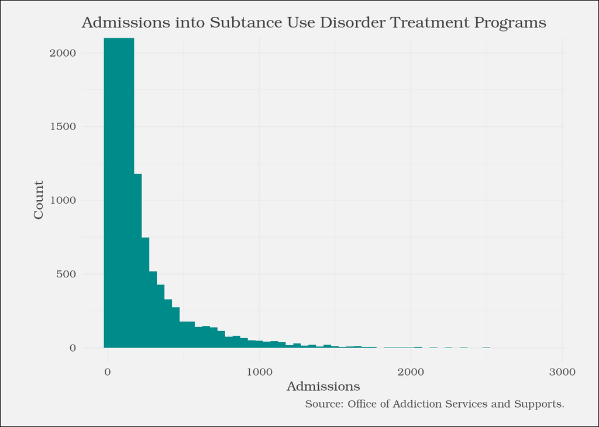

```r
# Plot showing outliers and skewed data
ggplot(chemical_dependance, aes(x = admissions)) +
  geom_histogram(binwidth = 50, fill = "darkcyan") +
  coord_cartesian(ylim = c(0, 2000)) +
  cool_theme() +
  labs(title = "Admissions into Subtance Use Disorder Treatment Programs",
       x = "Admissions",
       y = "Count",
       caption = "Source: Office of Addiction Services and Supports.")
```

```r
# Calculate z-score of admissions
mean_tip <- mean(chemical_dependance$admissions)
sd_tip <- sd(chemical_dependance$admissions)
z_tip <- (abs(mean_tip - chemical_dependance$admissions) / sd_tip)

# Remove outliers (<3 sd from mean)
chemical_dependance_no_outliers <- chemical_dependance %>%
  filter(z_tip < 3)

summary(chemical_dependance_no_outliers)
```

```
##       year      county_of_program_location program_category
##  Min.   :2007   Length:97450               Length:97450
##  1st Qu.:2010   Class :character           Class :character
##  Median :2014   Mode  :character           Mode  :character
##  Mean   :2014
##  3rd Qu.:2018
##  Max.   :2021
##  service_type        age_group         primary_substance_group   admissions
##  Length:97450       Length:97450       Length:97450            Min.   :  1.00
##  Class :character   Class :character   Class :character        1st Qu.:  2.00
##  Mode  :character   Mode  :character   Mode  :character        Median :  8.00
##                                                                Mean   : 27.91
##                                                                3rd Qu.: 26.00
##                                                                Max.   :410.00
```

After loading and scrapping the XML file, we performed summary statistics by identifying outliers and removing the outliers. We are assuming that outliers are 3 standard deviations away from the mean. The mean is higher than the median, which means that there are large positive outliers that are skewing the distribution to the right. For instance, the max admission is 2,861 which occurred in New York in 2007. Furthermore, we created a histogram to show that distribution.

## Question 3

Structure the data relationally, at a minimum, you should have four tibbles or data frames as follows: `county`, `program_category`, `primary_substance_group`, and `admission_data`.

```r
# county tibble
county <- chemical_dependance_no_outliers %>%
  select(county_of_program_location) %>%
  mutate(county_code = recode(county_of_program_location, "Albany" = "AL",
    "Cattaraugus" = "CA", "Chenango" = "CN", "Delaware" = "DE", "Franklin" =    "FR",
    "Lewis" =   "LE", "Montgomery"= "MG", "Oneida" = "ON", "Orleans" = "OL",
    "Queens" = "NY", "Saint Lawrence" = "SL", "Schuyler" = "SY", "Sullivan" = "SV",
    "Warren" = "WR", "Wyoming" = "WY", "Allegany" = "AG", "Cayuga" = "CY",
    "Clinton" = "CL", "Dutchess" = "DU", "Fulton" = "FU", "Herkimer" = "HE",
    "Livingston" = "LI", "Nassau" = "NA", "Onondaga" = "OD", "Oswego" = "OS",
    "Rensselaer" = "RE", "Saratoga" = "SA", "Seneca" = "SE", "Tioga" = "TI",
    "Washington" = "WS", "Yates" = "YA", "Bronx" = "NY", "New York" = "NY",
    "Richmond" = "NY", "Kings" = "NY", "Columbia" = "CO", "Erie" = "ER",
    "Genesee" = "GE", "Jefferson" = "JE","Madison" = "MA", "Ontario" = "OT",
    "Otsego" = "OG", "Schenectady" = "SC",  "Steuben" = "ST", "Tompkins" = "TO",
    "Wayne" = "WA", "Broome" = "BM", "Chemung" = "CM", "Cortland" = "CR",
    "Essex" = "ES", "Greene" = "GR", "Monroe" = "MO", "Niagara" = "NI",
    "Orange" = "OR","Putnam" = "PU", "Rockland" = "RO", "Schoharie" = "SH",
   "Suffolk" = "SU", "Ulster" = "UL", "Westchester" = "WE", "Allegany" = "AG",
    "Chautauqua" = "CH", "Cortland" = "CR", "Herkimer" = "HE", "Ulster" = "UL",
    "Cattaraugus" = "CA")) %>%
  distinct()

county
```

```
## # A tibble: 61 × 2
##    county_of_program_location county_code
##    <chr>                      <chr>
##  1 Albany                     AL
##  2 Allegany                   AG
##  3 Bronx                      NY
##  4 Broome                     BM
##  5 Cattaraugus                CA
##  6 Cayuga                     CY
##  7 Chautauqua                 CH
##  8 Chemung                    CM
##  9 Chenango                   CN
## 10 Clinton                    CL
## # … with 51 more rows
```

```r
# program_category tibble
program_category <- chemical_dependance_no_outliers %>%
  select(program_category) %>%
  mutate(program_code = recode(program_category, "Crisis" = "CR", "Inpatient" = "IN",  "Opioid Treatment Program" = "OPT", "Residential" = "R", "Outpatient" = "OUT", "Specialized" = "SP")) %>%
  distinct()

program_category
```

```
## # A tibble: 6 × 2
##   program_category         program_code
##   <chr>                    <chr>
## 1 Crisis                   CR
## 2 Inpatient                IN
## 3 Opioid Treatment Program OPT
## 4 Outpatient               OUT
## 5 Residential              R
## 6 Specialized              SP
```

```r
# primary_substance_group tibble
primary_substance_group <- chemical_dependance_no_outliers %>%
  select(primary_substance_group) %>%
  distinct() %>%
  mutate(substance_code = recode(primary_substance_group, "Heroin" = "H", "All Others" = "ALO", "Other Opioids" = "OOP", "Alcohol" = "AL", "Cocaine" = "C", "Marijuana" = "M", "None" = "N"))

primary_substance_group
```

```
## # A tibble: 7 × 2
##   primary_substance_group substance_code
##   <chr>                   <chr>
## 1 Heroin                  H
## 2 All Others              ALO
## 3 Other Opioids           OOP
## 4 Alcohol                 AL
## 5 Cocaine                 C
## 6 Marijuana               M
## 7 None                    N
```

```r
# admissions_data tibble
admissions_data <- chemical_dependance_no_outliers %>%
  right_join(program_category, by = "program_category") %>%
  right_join(primary_substance_group, by = "primary_substance_group") %>%
  right_join(county, by = "county_of_program_location") %>%
  select(year, county_code, county_of_program_location, program_code, program_category, service_type, age_group, substance_code, primary_substance_group,admissions) %>%
  select(-county_of_program_location, -program_category, -primary_substance_group)

head(admissions_data)
```

```
## # A tibble: 6 × 7
##    year county_code program_code service_type            age_g…¹ subst…² admis…³
##   <dbl> <chr>       <chr>        <chr>                   <chr>   <chr>     <dbl>
## 1  2007 AL          CR           Medical Managed Detoxi… Under … H             4
## 2  2007 AL          CR           Medical Managed Detoxi… 18 thr… ALO           2
## 3  2007 AL          CR           Medical Managed Detoxi… 18 thr… OOP           6
## 4  2007 AL          CR           Medical Managed Detoxi… 18 thr… H           132
## 5  2007 AL          CR           Medical Managed Detoxi… 18 thr… AL           35
## 6  2007 AL          CR           Medical Managed Detoxi… 25 thr… ALO           8
## # … with abbreviated variable names ¹age_group, ²substance_code, ³admissions
```

## Question 4

Create a function called `annualAdmissions()` that derives the total number of reported admissions that transpired each year, for the entire state of NY and displays the results using a line chart. Annotate the chart to show the year with the highest number of admissions. Note: the year should be on the x-axis and the number of admissions on the y-axis. Explain the chart.

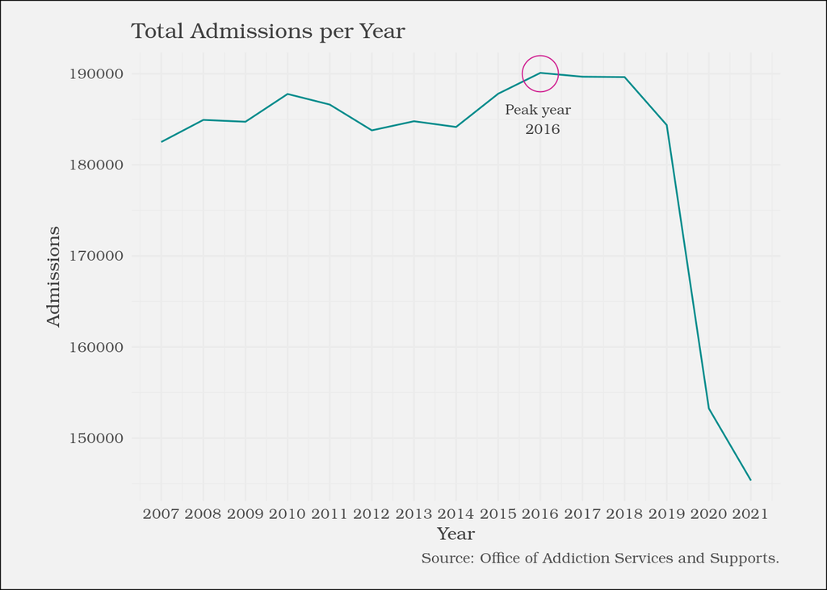

```r
# Make function - still need to annotate
annualAdmissions <- function() {
  xx <- chemical_dependance_no_outliers %>%
    group_by(year) %>%
    summarize(total_admissions = sum(admissions)) %>%
    ggplot(aes(x = year, y = total_admissions)) +
    geom_line(stat = "identity", color = "darkcyan") +
    scale_x_continuous(name = "Year", breaks = seq(from = 2007, to = 2022, by = 1)) +
    cool_theme() +
    scale_y_continuous(name = "Admissions") +
    labs(title = "Total Admissions per Year",
         caption =  str_wrap("Source: Office of Addiction Services and Supports.")) +
    annotate(geom = "point", x = 2016, y = 190000,
             size = 10, shape = 21, fill="transparent", color = "violetred") +
     annotate(geom = "text", x = 2016, y = 185000,
             label = "Peak year \n 2016", family = "Bookman",
             color = "gray25", size = 3)
  return(xx)
}

# Call function
annualAdmissions()
```

We created a function called `annualAdmissions()` that calculates the total amount of admissions for each year (from 2007 - 2021) and creates a line chart and labels the year where the highest admissions. The data used is the data without outliers. Due to the skewed distibution (shown in the Question 2 graph), we decided to use the data without the outliers to have a better understanding of the data. The line chart shows that from 2007 to to 2016 the number of admissions increased and decreased minimally. The peak year is of admissions is 2016, and there was a significant drop from 2018 to 2021.

## Question 5

Analyze the percentage of admissions for each county and visualize the results for the top 5 counties using a bar chart. Explain the results.

```r
# Make tibble of percentages
counties_percent <- admissions_data %>%
group_by(county_code) %>%
summarize(total_admissions = sum(admissions),
          total_percentages = round(sum(admissions)/sum(admissions_data$admissions), 3))

counties_percent
```

```
## # A tibble: 57 × 3
##    county_code total_admissions total_percentages
##    <chr>                  <dbl>             <dbl>
##  1 AG                      4770             0.002
##  2 AL                    100457             0.037
##  3 BM                     50427             0.019
##  4 CA                     11078             0.004
##  5 CH                     19911             0.007
##  6 CL                     12882             0.005
##  7 CM                     18021             0.007
##  8 CN                      5046             0.002
##  9 CO                      6998             0.003
## 10 CR                      9216             0.003
## # … with 47 more rows
```

```r
# Top counties
top_counties <- counties_percent %>%
  arrange(total_admissions) %>%
  top_n(5,total_admissions)

top_counties
```

```
## # A tibble: 5 × 3
##   county_code total_admissions total_percentages
##   <chr>                  <dbl>             <dbl>
## 1 OD                    133538             0.049
## 2 WE                    134989             0.05
## 3 ER                    138703             0.051
## 4 SU                    169479             0.062
## 5 NY                    759113             0.279
```

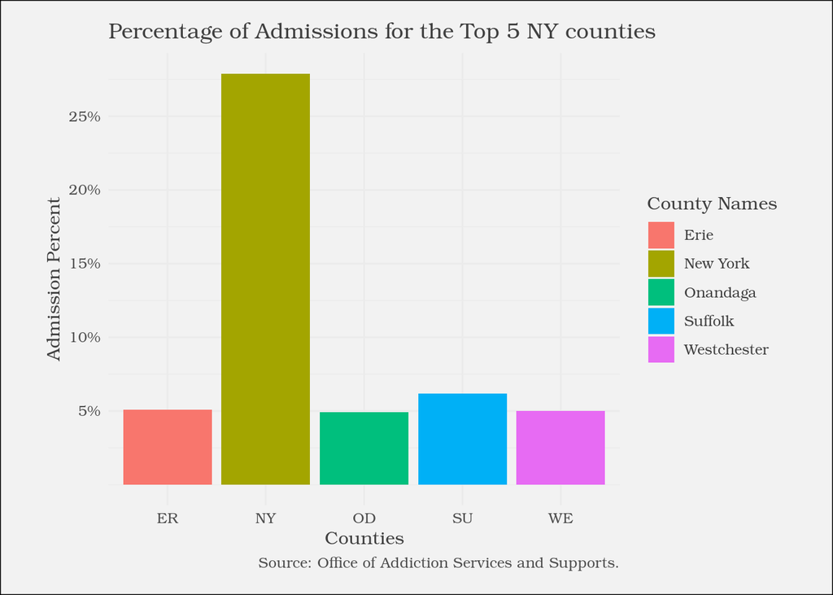

```r
# Make graph
ggplot(top_counties, aes(x = county_code, y = total_percentages, fill = county_code)) +
  geom_bar(stat = 'identity') +
  labs(x = "Counties", y = "Admission Percent",
       title = "Percentage of Admissions for the Top 5 NY counties",
        caption = str_wrap("Source: Office of Addiction Services and Supports.")) +
  cool_theme() +
  scale_y_continuous(labels = scales::percent,
                     breaks = seq(from = 0.05, to = 0.30, by = 0.05)) +
  scale_fill_discrete(name = "County Names", labels = c("Erie", "New York", "Onandaga",
                                                           "Suffolk", "Westchester"))
```

Analyzing the percentage of admissions for each country. We grouped by county and calculated the total admissions by county as a percentage of total admissions from 2007-2021. New York, which includes Queens, Bronx, New York City(usually Manhattan) Kings and Richmond county, Erie, Onondaga, Westchester, and Suffolk were the top five counties with the highest percentage of admissions. New York is the top county but that also means that it covers a larger area than the rest of the counties. Furthermore,New York population is concentrated in the boroughs, which makes sense that NY is the highest county with the top % of admissions.

## Question 6

Filter the data, using a regular expression, and extract all admissions to the various “Rehab” facilities; i.e. your regex should match all facilities that include the word rehab, rehabilitation, etc. Using the filtered data, identify which substance is the most prominent among each age group. Visualize and explain the results.

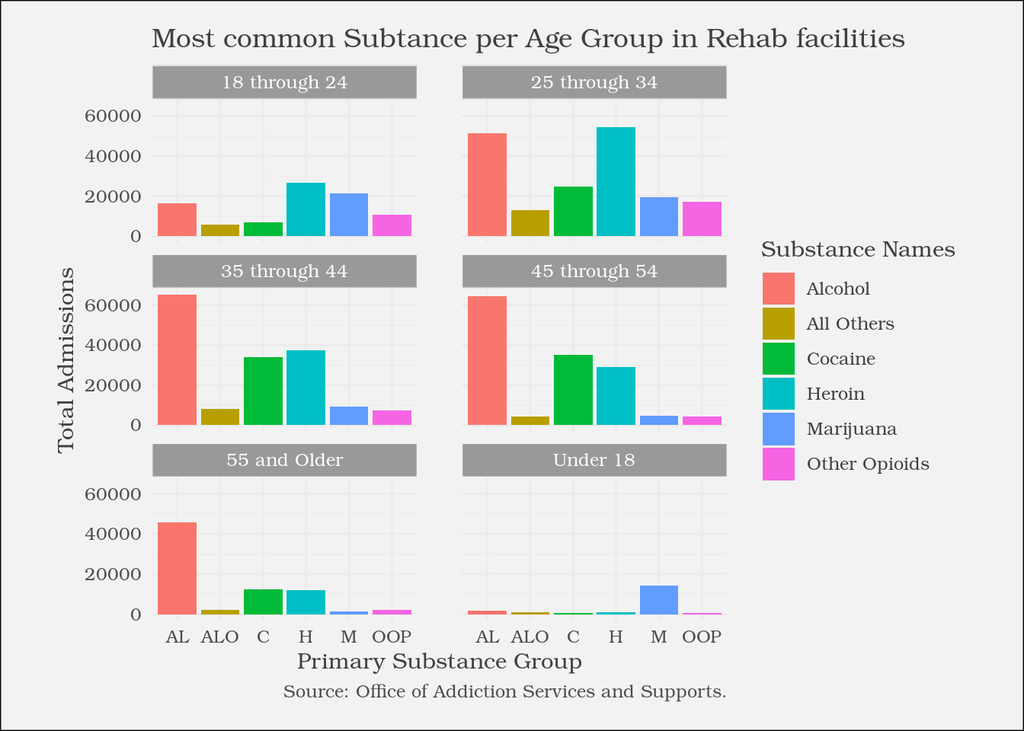

```r
# Filter for "Rehab" facilities
admissions_data %>%
  filter(str_detect(service_type, 'Rehab|Rehabilitation')) %>%
  select(service_type, age_group, substance_code, admissions) %>%
  group_by_at(vars(substance_code, age_group)) %>%
  summarize(total_admissions = sum(admissions), .groups = "keep") %>%
  # Make graph
  ggplot(aes(x = substance_code, y = total_admissions, fill = substance_code)) +
  geom_bar(stat = 'identity') + facet_wrap(vars(age_group), ncol = 2, dir = "h") +
  labs(x ="Primary Substance Group",
       y = "Total Admissions",
       title = "Most common Subtance per Age Group in Rehab facilities",
       caption =  str_wrap("Source: Office of Addiction Services and Supports.")) +
  cool_theme() +
  theme(panel.spacing.x = unit(1.5, "lines"),
        strip.background = element_rect(fill = "gray60",color = "gray95"),
        strip.text = element_text(color = "white")) +
  scale_fill_discrete(name = "Substance Names", labels = c("Alcohol", "All Others", "Cocaine",
                                                           "Heroin", "Marijuana", "Other Opioids"))
```

Filtering the data using a regex expression that matches all facilities that include rehab and rehabilitation. With the filtered data we identified which substance is the most prominent among each age group. For instance, age 35-44 has the highest total admissions for alcohol. 18-24 and 25-34 have the highest admission for heroin. For age groups 55+ and 45-55 the highest substance is alcohol, and for under 18 it is marijuana.